# Untitled

Ben Williams

January 22, 2016

We will began by simulating pollock exploitable biomass for the GOA as a parametric (equation 1a) or nonparametric (equation 1b) random function the time series of pollock exploitable biomass for 1988 (beginning of domestic only vessels in the fishery) to 2015:

$$B_{sim}=rv\sim\Lambda(\mu_{obs},\sigma^2_{obs})~~1a,$$
or
$$B_{sim}=rv\sim(\in\{B_{1988},...,B_{2015}\})~~1b.$$

# Biomass

The spawning stock biomass values from 1988-2013 are bimodal.

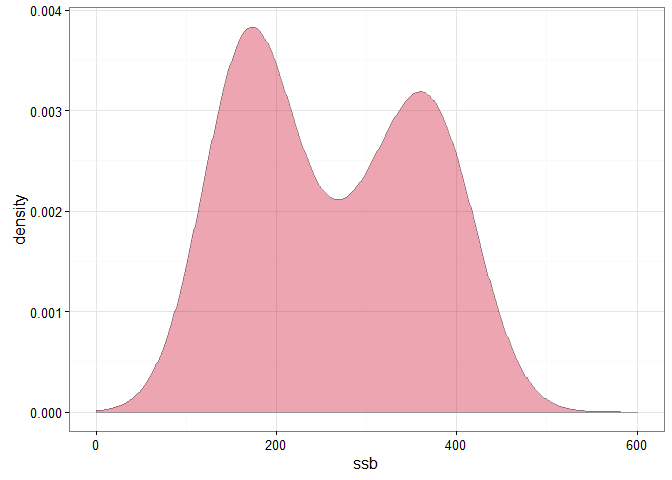

Figure 1. Pollock SSB density for 1988-2013.

The question then is how to best sample this parametrically?

**Option 1** is to find the mean and sigma of the modes  
Generate $\lambda$, $\mu$ and $\sigma$ for the distributions  
Sample from normal distribution for each mode based upon the $\lambda$.

```
## number of iterations= 20
```

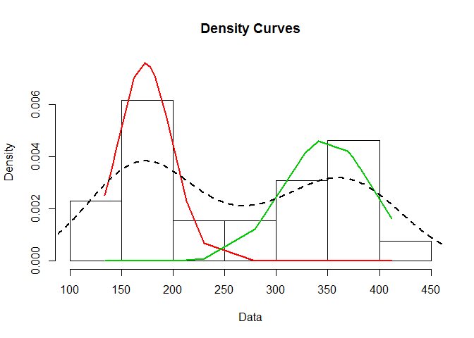

Figure 2. Pollock SSB bimodal distribution fit with two normal distributions.

$\lambda$ = 0.4945108, 0.5054892,  
$\mu$ = 172.7158555, 349.3449468 and  
$\sigma$ = 26.0581161, 43.0805556.

Twenty-six samples (one rep) from a normal distribution for each mode, combined.

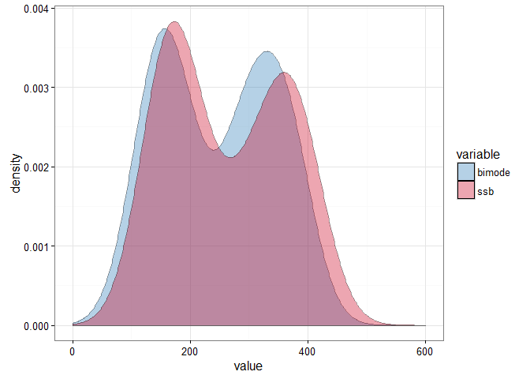

Figure 3. Comparison of pollock SSB density for 1988-2013 and bimodal distribution estimate.

**Option 2** is to sample from a normal distribution based upon the mean and sigma (parameters arrived at via MLE).

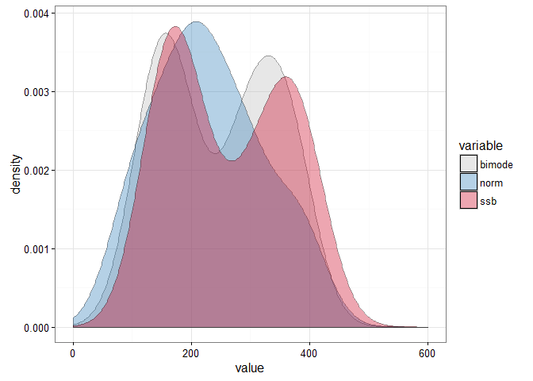

Figure 4. Comparison of pollock SSB density for 1988-2013 and normal distribution estimate.

**Option 3** is to sample from a lognormal distribution based upon the mean and sigma (parameters arrived at via MLE).

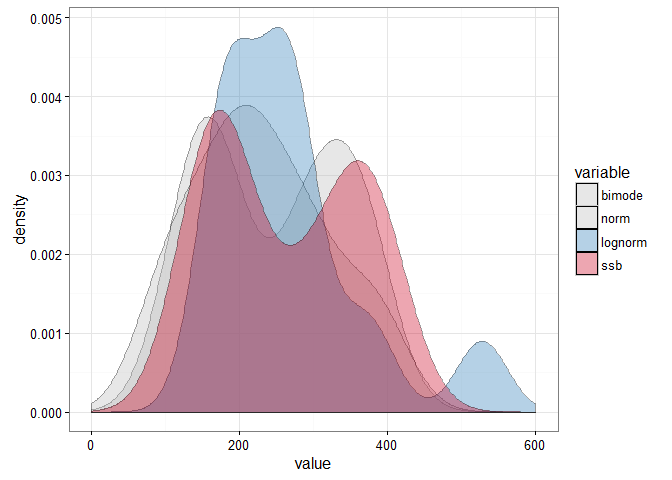

Figure 5. Comparison of pollock SSB density for 1988-2013 and lognormal distribution estimate.

*Non-parametric sample* Just because…

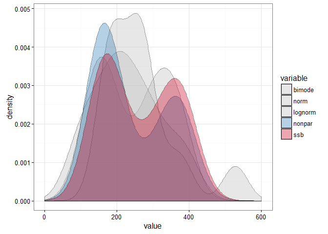

Figure 6. Comparison of pollock SSB density for 1988-2013 and a non-parametric distribution estimate.

# Recruits

**Option 1** is to sample from a lognormal distribution based upon the mean and sigma (parameters arrived at via MLE).

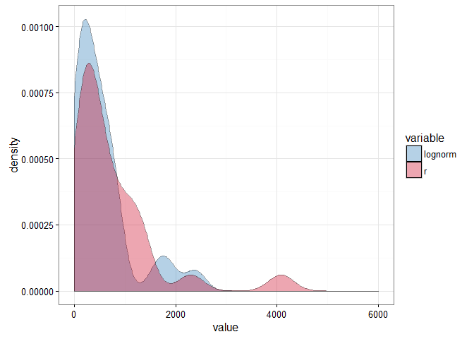

Figure 7. Comparison of pollock recruitment density for 1988-2013 and lognormal distribution estimate.

*Non-parametric sample* Just because…

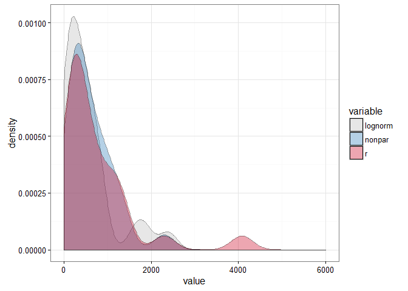

Figure 8. Comparison of pollock recruitment density for 1988-2013 and a non-parametric distribution estimate.